# Assignment2

### Team name:

[figure not shown]

Image created by Dall-E 3 open-AI with Prompt: A logo for a deep learning university team called "Persian CUDA", featuring a fierce stylized Persian cat at the top, three Persian male students in futuristic uniforms below, and the text "Persian CUDA - Deep Learning Team" in bold lettering. The design should have a shield shape, integrate the NVIDIA logo subtly, and use a dark teal and beige color scheme. The style should be modern, sleek, and slightly tech-inspired, with clean lines and geometric balance

### - Fine-tune ResNet, ConvNext and EfficientNet for your augmented dataset for human/robot classification and compare them.

### - Compare the following on a model of your choice: Fine-Tuned model, model as fixed feature extractor, and model with a Combined Approach

# ____________________________ Data ____________________________

```python
from torchvision import datasets, transforms
from torch.utils.data import DataLoader, ConcatDataset
import torch
import torch.nn as nn
from tqdm import tqdm;
```

```python
import os
import shutil
from tqdm import tqdm
import numpy as np
import matplotlib.pyplot as plt

import torch
import torch.nn as nn
import torch.nn.functional as F
import torchvision
from torchvision import datasets, models, transforms
from torchvision.utils import save_image
```

As noralization is part of data transformation, we need the means and stds for the three chanels. I'll begin by obtaining these values on the 'training + validation' data as a whole, since no information from test data should leak to the model at any point (totally unseen data). Later on, when I'm evaluating the model on the test set, I will have to use the means and stds obtained over 'training + validation' to perform transforms. Because again, the model should "supposedly" have no information whatsoever of what it will be up against (test data).

```python
# Resize and ToTensor only (no normalization yet)
temp_transform = transforms.Compose([
    transforms.Resize((224, 224)),
    transforms.ToTensor()
])

train_set = datasets.ImageFolder("dataset/train", transform=temp_transform)
val_set = datasets.ImageFolder("dataset/val", transform=temp_transform)

train_and_val = ConcatDataset([train_set, val_set])

loader = DataLoader(train_and_val, batch_size=32, shuffle=False)
```

```python
# Get mean and std for the R, G, and B channels
def get_mean_std(loader):
    mean = 0.
    std = 0.
    nb_samples = 0.

    for data, _ in tqdm(loader):
        batch_samples = data.size(0)
        data = data.view(batch_samples, data.size(1), -1)  # flatten H and W
        mean += data.mean(2).sum(0)
        std += data.std(2).sum(0)
        nb_samples += batch_samples

    mean /= nb_samples
    std /= nb_samples
    return mean, std
```

```python
mean, std = get_mean_std(loader)
print(f"Calculated Mean: {mean}")
print(f"Calculated Std: {std}")
```

```
Calculated Mean: tensor([0.4704, 0.4458, 0.4169])
Calculated Std: tensor([0.2250, 0.2159, 0.2180])
```

Now the pre-trainning transformers

```python
train_transform = transforms.Compose([
    transforms.Resize((224, 224)),
    transforms.RandomHorizontalFlip(),
    transforms.RandomRotation(15),
    transforms.ColorJitter(brightness=0.2, contrast=0.2),
    transforms.ToTensor(),
    transforms.Normalize(mean.tolist(), std.tolist())
])

val_transform = transforms.Compose([
    transforms.Resize((224, 224)),
    transforms.ToTensor(),
    transforms.Normalize(mean.tolist(), std.tolist())
])

test_transform = transforms.Compose([
    transforms.Resize((224, 224)),
    transforms.ToTensor(),
    transforms.Normalize(mean.tolist(), std.tolist())
])
```

```python
train_dataset = datasets.ImageFolder('dataset/train', transform=train_transform)
val_dataset   = datasets.ImageFolder('dataset/val', transform=val_transform)
test_dataset  = datasets.ImageFolder('dataset/test', transform=test_transform)

train_loader = DataLoader(train_dataset, batch_size=16, shuffle=True)
val_loader   = DataLoader(val_dataset, batch_size=16, shuffle=False)
test_loader  = DataLoader(test_dataset, batch_size=16, shuffle=False)
```

Now that the data is ready, we can proceed to the Models

# ____________________________ Models ____________________________

```python
torch.cuda.is_available()
```

```
True
```

```python
device = torch.device("cuda")
```

```python
from torch.utils.tensorboard import SummaryWriter
```

```python
# from torchvision.transforms import v2
# cutmix = v2.CutMix(num_classes=NUM_CLASSES)
```

```python
# Utility functions defined below are adapted from lecture material by Angel Villar Coralles.

def train_epoch(model, train_loader, optimizer, criterion, epoch, device):
    """ Training a model for one epoch """

    loss_list = []
    for i, (images, labels) in enumerate(train_loader):
        # images, labels = cutmix(images labels)
        images = images.to(device)
        labels = labels.to(device)

        # Clear gradients w.r.t. parameters
        optimizer.zero_grad()

        # Forward pass to get output/logits
        outputs = model(images)

        # Calculate Loss: softmax --> cross entropy loss
        loss = criterion(outputs, labels)
        loss_list.append(loss.item())

        # Getting gradients w.r.t. parameters
        loss.backward()

        # Updating parameters
        optimizer.step()

    mean_loss = np.mean(loss_list)
    return mean_loss, loss_list


@torch.no_grad()
def eval_model(model, eval_loader, criterion, device):
    """ Evaluating the model for either validation or test """
    correct = 0
    total = 0
    loss_list = []

    for images, labels in eval_loader:
        images = images.to(device)
        labels = labels.to(device)

        # Forward pass only to get logits/output
        outputs = model(images)

        loss = criterion(outputs, labels)
        loss_list.append(loss.item())

        # Get predictions from the maximum value
        preds = torch.argmax(outputs, dim=1)
        correct += len( torch.where(preds==labels)[0] )
        total += len(labels)

    # Total correct predictions and loss
    accuracy = correct / total * 100
    loss = np.mean(loss_list)

    return accuracy, loss


def train_model(model, optimizer, scheduler, criterion, train_loader, valid_loader, num_epochs, tboard=None, start_epoch=0):
    """ Training a model for a given number of epochs"""

    train_loss = []
    val_loss =  []
    loss_iters = []
    valid_acc = []
    assert tboard is not None, f"Tensorboard must be provided!"

    for epoch in tqdm(range(num_epochs)):

        # validation epoch
        model.eval()  # important for dropout and batch norms
        accuracy, loss = eval_model(
                    model=model, eval_loader=valid_loader,
                    criterion=criterion, device=device
            )
        valid_acc.append(accuracy)
        val_loss.append(loss)
        tboard.add_scalar(f'Accuracy/Valid', accuracy, global_step=epoch+start_epoch)
        tboard.add_scalar(f'Loss/Valid', loss, global_step=epoch+start_epoch)

        # training epoch
        model.train()  # important for dropout and batch norms
        mean_loss, cur_loss_iters = train_epoch(
                model=model, train_loader=train_loader, optimizer=optimizer,
                criterion=criterion, epoch=epoch, device=device
            )
        scheduler.step()
        train_loss.append(mean_loss)
        tboard.add_scalar(f'Loss/Train', mean_loss, global_step=epoch+start_epoch)

        loss_iters = loss_iters + cur_loss_iters

        if(epoch % 5 == 0 or epoch==num_epochs-1):
            print(f"Epoch {epoch+1}/{num_epochs}")
            print(f"    Train loss: {round(mean_loss, 5)}")
            print(f"    Valid loss: {round(loss, 5)}")
            print(f"    Accuracy: {accuracy}%")
            print("\n")

    print(f"Training completed")
    return train_loss, val_loss, loss_iters, valid_acc
```

```python
def save_model(model, optimizer, epoch, stats):
    """ Saving model checkpoint """

    if(not os.path.exists("models")):
        os.makedirs("models")
    savepath = f"models/checkpoint_epoch_{epoch}.pth"

    torch.save({
        'epoch': epoch,
        'model_state_dict': model.state_dict(),
        'optimizer_state_dict': optimizer.state_dict(),
        'stats': stats
    }, savepath)
    return


def load_model(model, optimizer, savepath):
    """ Loading pretrained checkpoint """

    checkpoint = torch.load(savepath)
    model.load_state_dict(checkpoint['model_state_dict'])
    optimizer.load_state_dict(checkpoint['optimizer_state_dict'])
    epoch = checkpoint["epoch"]
    stats = checkpoint["stats"]

    return model, optimizer, epoch, stats


def smooth(f, K=5):
    """ Smoothing a function using a low-pass filter (mean) of size K """
    kernel = np.ones(K) / K
    f = np.concatenate([f[:int(K//2)], f, f[int(-K//2):]])  # to account for boundaries
    smooth_f = np.convolve(f, kernel, mode="same")
    smooth_f = smooth_f[K//2: -K//2]  # removing boundary-fixes
    return smooth_f

# Using common default random seed 13
def set_random_seed(random_seed=None):
    """
    Using random seed for numpy and torch
    """
    if(random_seed is None):
        random_seed = 13
    os.environ['PYTHONHASHSEED'] = str(random_seed)
    np.random.seed(random_seed)
    torch.manual_seed(random_seed)
    torch.cuda.manual_seed_all(random_seed)
    return
```

### Finetuning **ResNet18**

```python
from torchvision.models import resnet18
set_random_seed()
model = resnet18(pretrained=True)
```

```python
print(model.fc)
```

```
Linear(in_features=512, out_features=1000, bias=True)
```

```python
# replacing classification head with a single linear layer that outputs 2 logits
# It is more streamlined to get the head number of inputs as below
num_logits = model.fc.in_features
# model.fc = nn.Linear(num_logits, 2)
model.fc = nn.Sequential(
    nn.Linear(num_logits, 512),
    nn.ReLU(),
    nn.Dropout(0.2),
    nn.Linear(512, 2)
)

model = model.to(device)
```

```python
model
```

```
ResNet(
  (conv1): Conv2d(3, 64, kernel_size=(7, 7), stride=(2, 2), padding=(3, 3), bias=False)
  (bn1): BatchNorm2d(64, eps=1e-05, momentum=0.1, affine=True, track_running_stats=True)
  (relu): ReLU(inplace=True)
  (maxpool): MaxPool2d(kernel_size=3, stride=2, padding=1, dilation=1, ceil_mode=False)
  (layer1): Sequential(
    (0): BasicBlock(
      (conv1): Conv2d(64, 64, kernel_size=(3, 3), stride=(1, 1), padding=(1, 1), bias=False)
      (bn1): BatchNorm2d(64, eps=1e-05, momentum=0.1, affine=True, track_running_stats=True)
      (relu): ReLU(inplace=True)
      (conv2): Conv2d(64, 64, kernel_size=(3, 3), stride=(1, 1), padding=(1, 1), bias=False)
      (bn2): BatchNorm2d(64, eps=1e-05, momentum=0.1, affine=True, track_running_stats=True)
    )
    (1): BasicBlock(
      (conv1): Conv2d(64, 64, kernel_size=(3, 3), stride=(1, 1), padding=(1, 1), bias=False)
      (bn1): BatchNorm2d(64, eps=1e-05, momentum=0.1, affine=True, track_running_stats=True)
      (relu): ReLU(inplace=True)
      (conv2): Conv2d(64, 64, kernel_size=(3, 3), stride=(1, 1), padding=(1, 1), bias=False)
      (bn2): BatchNorm2d(64, eps=1e-05, momentum=0.1, affine=True, track_running_stats=True)
    )
  )
  (layer2): Sequential(
    (0): BasicBlock(
      (conv1): Conv2d(64, 128, kernel_size=(3, 3), stride=(2, 2), padding=(1, 1), bias=False)
      (bn1): BatchNorm2d(128, eps=1e-05, momentum=0.1, affine=True, track_running_stats=True)
      (relu): ReLU(inplace=True)
      (conv2): Conv2d(128, 128, kernel_size=(3, 3), stride=(1, 1), padding=(1, 1), bias=False)
      (bn2): BatchNorm2d(128, eps=1e-05, momentum=0.1, affine=True, track_running_stats=True)
      (downsample): Sequential(
        (0): Conv2d(64, 128, kernel_size=(1, 1), stride=(2, 2), bias=False)
        (1): BatchNorm2d(128, eps=1e-05, momentum=0.1, affine=True, track_running_stats=True)
      )
    )
    (1): BasicBlock(
      (conv1): Conv2d(128, 128, kernel_size=(3, 3), stride=(1, 1), padding=(1, 1), bias=False)
      (bn1): BatchNorm2d(128, eps=1e-05, momentum=0.1, affine=True, track_running_stats=True)
      (relu): ReLU(inplace=True)
      (conv2): Conv2d(128, 128, kernel_size=(3, 3), stride=(1, 1), padding=(1, 1), bias=False)
      (bn2): BatchNorm2d(128, eps=1e-05, momentum=0.1, affine=True, track_running_stats=True)
    )
```

[output cut: 34 more lines]

```
      (conv1): Conv2d(512, 512, kernel_size=(3, 3), stride=(1, 1), padding=(1, 1), bias=False)
      (bn1): BatchNorm2d(512, eps=1e-05, momentum=0.1, affine=True, track_running_stats=True)
      (relu): ReLU(inplace=True)
      (conv2): Conv2d(512, 512, kernel_size=(3, 3), stride=(1, 1), padding=(1, 1), bias=False)
      (bn2): BatchNorm2d(512, eps=1e-05, momentum=0.1, affine=True, track_running_stats=True)
    )
  )
  (avgpool): AdaptiveAvgPool2d(output_size=(1, 1))
  (fc): Sequential(
    (0): Linear(in_features=512, out_features=512, bias=True)
    (1): ReLU()
    (2): Dropout(p=0.2, inplace=False)
    (3): Linear(in_features=512, out_features=2, bias=True)
  )
)
```

```python
# classification loss function
criterion = nn.CrossEntropyLoss()

# Observe that all parameters are being optimized
optimizer = torch.optim.Adam(model.parameters(), lr=1e-4)

# Decay LR by a factor of 3 every 5 epochs
scheduler = torch.optim.lr_scheduler.StepLR(optimizer, step_size=5, gamma=1/3)
```

```python
TBOARD_LOGS = os.path.join(os.getcwd(), "tboard_logs", "Task1_Logs", "ResNet18_Tuned")
if not os.path.exists(TBOARD_LOGS):
    os.makedirs(TBOARD_LOGS)

shutil.rmtree(TBOARD_LOGS)
writer = SummaryWriter(TBOARD_LOGS)
```

```python
train_loss, val_loss, loss_iters, valid_acc = train_model(
        model=model, optimizer=optimizer, scheduler=scheduler, criterion=criterion,
        train_loader=train_loader, valid_loader=val_loader, num_epochs=15, tboard=writer
    )
```

```
    Train loss: 0.44058
    Valid loss: 0.6536
    Accuracy: 71.875%
```

```
    Train loss: 0.00769
    Valid loss: 0.00456
    Accuracy: 100.0%
```

```
    Train loss: 0.00339
    Valid loss: 0.00604
    Accuracy: 100.0%
```

```
    Train loss: 0.00497
    Valid loss: 0.00582
    Accuracy: 100.0%


Training completed
```

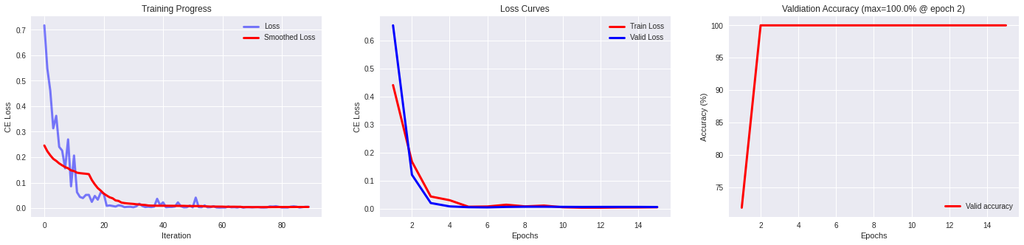

```python
plt.style.use('seaborn')
fig, ax = plt.subplots(1,3)
fig.set_size_inches(24,5)

smooth_loss = smooth(loss_iters, 31)
ax[0].plot(loss_iters, c="blue", label="Loss", linewidth=3, alpha=0.5)
ax[0].plot(smooth_loss, c="red", label="Smoothed Loss", linewidth=3, alpha=1)
ax[0].legend(loc="best")
ax[0].set_xlabel("Iteration")
ax[0].set_ylabel("CE Loss")
ax[0].set_title("Training Progress")

epochs = np.arange(len(train_loss)) + 1
ax[1].plot(epochs, train_loss, c="red", label="Train Loss", linewidth=3)
ax[1].plot(epochs, val_loss, c="blue", label="Valid Loss", linewidth=3)
ax[1].legend(loc="best")
ax[1].set_xlabel("Epochs")
ax[1].set_ylabel("CE Loss")
ax[1].set_title("Loss Curves")

epochs = np.arange(len(val_loss)) + 1
ax[2].plot(epochs, valid_acc, c="red", label="Valid accuracy", linewidth=3)
ax[2].legend(loc="best")
ax[2].set_xlabel("Epochs")
ax[2].set_ylabel("Accuracy (%)")
ax[2].set_title(f"Valdiation Accuracy (max={round(np.max(valid_acc),2)}% @ epoch {np.argmax(valid_acc)+1})")

plt.show()
```

### Finetuning **ConvNext**

```python
from torchvision.models import convnext_tiny
# set_random_seed()
model = convnext_tiny(pretrained=True)
```

```python
print(model.classifier)
```

```
Sequential(
  (0): LayerNorm2d((768,), eps=1e-06, elementwise_affine=True)
  (1): Flatten(start_dim=1, end_dim=-1)
  (2): Linear(in_features=768, out_features=1000, bias=True)
)
```

```python
model.classifier[0]
```

```
LayerNorm2d((768,), eps=1e-06, elementwise_affine=True)
```

```python
model.classifier = nn.Sequential(
    nn.Flatten(start_dim=1),
    nn.LayerNorm(768, eps=1e-6),
    nn.Linear(768, 512),
    nn.ReLU(),
    nn.Dropout(0.2),
    nn.Linear(512, 2)
)


model = model.to(device)
```

```python
model
```

```
ConvNeXt(
  (features): Sequential(
    (0): Conv2dNormActivation(
      (0): Conv2d(3, 96, kernel_size=(4, 4), stride=(4, 4))
      (1): LayerNorm2d((96,), eps=1e-06, elementwise_affine=True)
    )
    (1): Sequential(
      (0): CNBlock(
        (block): Sequential(
          (0): Conv2d(96, 96, kernel_size=(7, 7), stride=(1, 1), padding=(3, 3), groups=96)
          (1): Permute()
          (2): LayerNorm((96,), eps=1e-06, elementwise_affine=True)
          (3): Linear(in_features=96, out_features=384, bias=True)
          (4): GELU(approximate=none)
          (5): Linear(in_features=384, out_features=96, bias=True)
          (6): Permute()
        )
        (stochastic_depth): StochasticDepth(p=0.0, mode=row)
      )
      (1): CNBlock(
        (block): Sequential(
          (0): Conv2d(96, 96, kernel_size=(7, 7), stride=(1, 1), padding=(3, 3), groups=96)
          (1): Permute()
          (2): LayerNorm((96,), eps=1e-06, elementwise_affine=True)
          (3): Linear(in_features=96, out_features=384, bias=True)
          (4): GELU(approximate=none)
          (5): Linear(in_features=384, out_features=96, bias=True)
          (6): Permute()
        )
        (stochastic_depth): StochasticDepth(p=0.0058823529411764705, mode=row)
      )
      (2): CNBlock(
        (block): Sequential(
          (0): Conv2d(96, 96, kernel_size=(7, 7), stride=(1, 1), padding=(3, 3), groups=96)
          (1): Permute()
          (2): LayerNorm((96,), eps=1e-06, elementwise_affine=True)
          (3): Linear(in_features=96, out_features=384, bias=True)
          (4): GELU(approximate=none)
          (5): Linear(in_features=384, out_features=96, bias=True)
          (6): Permute()
```

[output cut: 198 more lines]

```
        )
        (stochastic_depth): StochasticDepth(p=0.1, mode=row)
      )
    )
  )
  (avgpool): AdaptiveAvgPool2d(output_size=1)
  (classifier): Sequential(
    (0): Flatten(start_dim=1, end_dim=-1)
    (1): LayerNorm((768,), eps=1e-06, elementwise_affine=True)
    (2): Linear(in_features=768, out_features=512, bias=True)
    (3): ReLU()
    (4): Dropout(p=0.2, inplace=False)
    (5): Linear(in_features=512, out_features=2, bias=True)
  )
)
```

```python
# classification loss function
criterion = nn.CrossEntropyLoss()

# Observe that all parameters are being optimized
optimizer = torch.optim.Adam(model.parameters(), lr=1e-4)

# Decay LR by a factor of 3 every 5 epochs
scheduler = torch.optim.lr_scheduler.StepLR(optimizer, step_size=5, gamma=1/3)
```

```python
TBOARD_LOGS = os.path.join(os.getcwd(), "tboard_logs", "Task1_Logs", "ConvNext_Tuned")
if not os.path.exists(TBOARD_LOGS):
    os.makedirs(TBOARD_LOGS)

shutil.rmtree(TBOARD_LOGS)
writer = SummaryWriter(TBOARD_LOGS)
```

```python
train_loss, val_loss, loss_iters, valid_acc = train_model(
        model=model, optimizer=optimizer, scheduler=scheduler, criterion=criterion,
        train_loader=train_loader, valid_loader=val_loader, num_epochs=15, tboard=writer
    )
```

```
    Train loss: 0.48383
    Valid loss: 0.6829
    Accuracy: 53.125%
```

```
    Train loss: 0.00217
    Valid loss: 0.00264
    Accuracy: 100.0%
```

```
    Train loss: 0.00136
    Valid loss: 0.00179
    Accuracy: 100.0%
```

```
    Train loss: 0.00134
    Valid loss: 0.00166
    Accuracy: 100.0%


Training completed
```

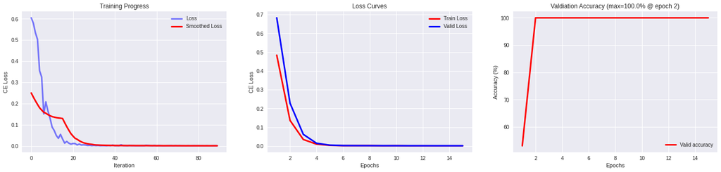

```python
plt.style.use('seaborn')
fig, ax = plt.subplots(1,3)
fig.set_size_inches(24,5)

smooth_loss = smooth(loss_iters, 31)
ax[0].plot(loss_iters, c="blue", label="Loss", linewidth=3, alpha=0.5)
ax[0].plot(smooth_loss, c="red", label="Smoothed Loss", linewidth=3, alpha=1)
ax[0].legend(loc="best")
ax[0].set_xlabel("Iteration")
ax[0].set_ylabel("CE Loss")
ax[0].set_title("Training Progress")

epochs = np.arange(len(train_loss)) + 1
ax[1].plot(epochs, train_loss, c="red", label="Train Loss", linewidth=3)
ax[1].plot(epochs, val_loss, c="blue", label="Valid Loss", linewidth=3)
ax[1].legend(loc="best")
ax[1].set_xlabel("Epochs")
ax[1].set_ylabel("CE Loss")
ax[1].set_title("Loss Curves")

epochs = np.arange(len(val_loss)) + 1
ax[2].plot(epochs, valid_acc, c="red", label="Valid accuracy", linewidth=3)
ax[2].legend(loc="best")
ax[2].set_xlabel("Epochs")
ax[2].set_ylabel("Accuracy (%)")
ax[2].set_title(f"Valdiation Accuracy (max={round(np.max(valid_acc),2)}% @ epoch {np.argmax(valid_acc)+1})")

plt.show()
```

### Finetuning **EfficientNet**

```python
from torchvision.models import efficientnet_b0
# set_random_seed()
model = efficientnet_b0(pretrained=True)
```

```python
print(model)
# print(model.classifier)
```

```
EfficientNet(
  (features): Sequential(
    (0): Conv2dNormActivation(
      (0): Conv2d(3, 32, kernel_size=(3, 3), stride=(2, 2), padding=(1, 1), bias=False)
      (1): BatchNorm2d(32, eps=1e-05, momentum=0.1, affine=True, track_running_stats=True)
      (2): SiLU(inplace=True)
    )
    (1): Sequential(
      (0): MBConv(
        (block): Sequential(
          (0): Conv2dNormActivation(
            (0): Conv2d(32, 32, kernel_size=(3, 3), stride=(1, 1), padding=(1, 1), groups=32, bias=False)
            (1): BatchNorm2d(32, eps=1e-05, momentum=0.1, affine=True, track_running_stats=True)
            (2): SiLU(inplace=True)
          )
          (1): SqueezeExcitation(
            (avgpool): AdaptiveAvgPool2d(output_size=1)
            (fc1): Conv2d(32, 8, kernel_size=(1, 1), stride=(1, 1))
            (fc2): Conv2d(8, 32, kernel_size=(1, 1), stride=(1, 1))
            (activation): SiLU(inplace=True)
            (scale_activation): Sigmoid()
          )
          (2): Conv2dNormActivation(
            (0): Conv2d(32, 16, kernel_size=(1, 1), stride=(1, 1), bias=False)
            (1): BatchNorm2d(16, eps=1e-05, momentum=0.1, affine=True, track_running_stats=True)
          )
        )
        (stochastic_depth): StochasticDepth(p=0.0, mode=row)
      )
    )
    (2): Sequential(
      (0): MBConv(
        (block): Sequential(
          (0): Conv2dNormActivation(
            (0): Conv2d(16, 96, kernel_size=(1, 1), stride=(1, 1), bias=False)
            (1): BatchNorm2d(96, eps=1e-05, momentum=0.1, affine=True, track_running_stats=True)
            (2): SiLU(inplace=True)
          )
          (1): Conv2dNormActivation(
            (0): Conv2d(96, 96, kernel_size=(3, 3), stride=(2, 2), padding=(1, 1), groups=96, bias=False)
```

[output cut: 389 more lines]

```
        (stochastic_depth): StochasticDepth(p=0.1875, mode=row)
      )
    )
    (8): Conv2dNormActivation(
      (0): Conv2d(320, 1280, kernel_size=(1, 1), stride=(1, 1), bias=False)
      (1): BatchNorm2d(1280, eps=1e-05, momentum=0.1, affine=True, track_running_stats=True)
      (2): SiLU(inplace=True)
    )
  )
  (avgpool): AdaptiveAvgPool2d(output_size=1)
  (classifier): Sequential(
    (0): Dropout(p=0.2, inplace=True)
    (1): Linear(in_features=1280, out_features=1000, bias=True)
  )
)
```

```python
model.classifier
```

```
Sequential(
  (0): Dropout(p=0.2, inplace=True)
  (1): Linear(in_features=1280, out_features=1000, bias=True)
)
```

```python
model.classifier = nn.Sequential(
    nn.Dropout(0.2),
    nn.Linear(1280, 512),
    nn.ReLU(),
    nn.Dropout(0.2),
    nn.Linear(512, 2)
)


model = model.to(device)
```

```python
model
```

```
EfficientNet(
  (features): Sequential(
    (0): Conv2dNormActivation(
      (0): Conv2d(3, 32, kernel_size=(3, 3), stride=(2, 2), padding=(1, 1), bias=False)
      (1): BatchNorm2d(32, eps=1e-05, momentum=0.1, affine=True, track_running_stats=True)
      (2): SiLU(inplace=True)
    )
    (1): Sequential(
      (0): MBConv(
        (block): Sequential(
          (0): Conv2dNormActivation(
            (0): Conv2d(32, 32, kernel_size=(3, 3), stride=(1, 1), padding=(1, 1), groups=32, bias=False)
            (1): BatchNorm2d(32, eps=1e-05, momentum=0.1, affine=True, track_running_stats=True)
            (2): SiLU(inplace=True)
          )
          (1): SqueezeExcitation(
            (avgpool): AdaptiveAvgPool2d(output_size=1)
            (fc1): Conv2d(32, 8, kernel_size=(1, 1), stride=(1, 1))
            (fc2): Conv2d(8, 32, kernel_size=(1, 1), stride=(1, 1))
            (activation): SiLU(inplace=True)
            (scale_activation): Sigmoid()
          )
          (2): Conv2dNormActivation(
            (0): Conv2d(32, 16, kernel_size=(1, 1), stride=(1, 1), bias=False)
            (1): BatchNorm2d(16, eps=1e-05, momentum=0.1, affine=True, track_running_stats=True)
          )
        )
        (stochastic_depth): StochasticDepth(p=0.0, mode=row)
      )
    )
    (2): Sequential(
      (0): MBConv(
        (block): Sequential(
          (0): Conv2dNormActivation(
            (0): Conv2d(16, 96, kernel_size=(1, 1), stride=(1, 1), bias=False)
            (1): BatchNorm2d(96, eps=1e-05, momentum=0.1, affine=True, track_running_stats=True)
            (2): SiLU(inplace=True)
          )
          (1): Conv2dNormActivation(
            (0): Conv2d(96, 96, kernel_size=(3, 3), stride=(2, 2), padding=(1, 1), groups=96, bias=False)
```

[output cut: 392 more lines]

```
    (8): Conv2dNormActivation(
      (0): Conv2d(320, 1280, kernel_size=(1, 1), stride=(1, 1), bias=False)
      (1): BatchNorm2d(1280, eps=1e-05, momentum=0.1, affine=True, track_running_stats=True)
      (2): SiLU(inplace=True)
    )
  )
  (avgpool): AdaptiveAvgPool2d(output_size=1)
  (classifier): Sequential(
    (0): Dropout(p=0.2, inplace=False)
    (1): Linear(in_features=1280, out_features=512, bias=True)
    (2): ReLU()
    (3): Dropout(p=0.2, inplace=False)
    (4): Linear(in_features=512, out_features=2, bias=True)
  )
)
```

```python
# classification loss function
criterion = nn.CrossEntropyLoss()

# Observe that all parameters are being optimized
optimizer = torch.optim.Adam(model.parameters(), lr=1e-4)

# Decay LR by a factor of 3 every 5 epochs
scheduler = torch.optim.lr_scheduler.StepLR(optimizer, step_size=5, gamma=1/3)
```

```python
TBOARD_LOGS = os.path.join(os.getcwd(), "tboard_logs", "Task1_Logs", "EfficientNet_Tuned")
if not os.path.exists(TBOARD_LOGS):
    os.makedirs(TBOARD_LOGS)

shutil.rmtree(TBOARD_LOGS)
writer = SummaryWriter(TBOARD_LOGS)
```

```python
train_loss, val_loss, loss_iters, valid_acc = train_model(
        model=model, optimizer=optimizer, scheduler=scheduler, criterion=criterion,
        train_loader=train_loader, valid_loader=val_loader, num_epochs=15, tboard=writer
    )
```

```
    Train loss: 0.65243
    Valid loss: 0.71807
    Accuracy: 43.75%
```

```
    Train loss: 0.10253
    Valid loss: 0.08715
    Accuracy: 100.0%
```

```
    Train loss: 0.0408
    Valid loss: 0.04348
    Accuracy: 100.0%
```

```
    Train loss: 0.04838
    Valid loss: 0.03507
    Accuracy: 100.0%


Training completed
```

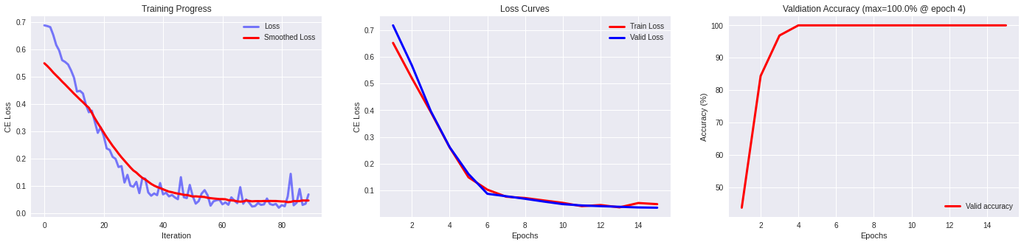

```python
plt.style.use('seaborn')
fig, ax = plt.subplots(1,3)
fig.set_size_inches(24,5)

smooth_loss = smooth(loss_iters, 31)
ax[0].plot(loss_iters, c="blue", label="Loss", linewidth=3, alpha=0.5)
ax[0].plot(smooth_loss, c="red", label="Smoothed Loss", linewidth=3, alpha=1)
ax[0].legend(loc="best")
ax[0].set_xlabel("Iteration")
ax[0].set_ylabel("CE Loss")
ax[0].set_title("Training Progress")

epochs = np.arange(len(train_loss)) + 1
ax[1].plot(epochs, train_loss, c="red", label="Train Loss", linewidth=3)
ax[1].plot(epochs, val_loss, c="blue", label="Valid Loss", linewidth=3)
ax[1].legend(loc="best")
ax[1].set_xlabel("Epochs")
ax[1].set_ylabel("CE Loss")
ax[1].set_title("Loss Curves")

epochs = np.arange(len(val_loss)) + 1
ax[2].plot(epochs, valid_acc, c="red", label="Valid accuracy", linewidth=3)
ax[2].legend(loc="best")
ax[2].set_xlabel("Epochs")
ax[2].set_ylabel("Accuracy (%)")
ax[2].set_title(f"Valdiation Accuracy (max={round(np.max(valid_acc),2)}% @ epoch {np.argmax(valid_acc)+1})")

plt.show()
```

### **ConvNext:** FineTuned vs Fixed Feqture Extractor vs Combined

I picked ConvNext because that **LayerNorm** really piqued my interest. Perhaps this will be an excuse to look further into it. The results for finetuned ConvNext are aleady depicted earlier. The following, contains experiments on using ConvNext as a fixed feature extractor, as well as combining this approach with full finetuning.

A) Fixed Feature Extractor

```python
from torchvision.models import convnext_tiny
fixedModel = convnext_tiny(pretrained=True)

for param in fixedModel.parameters():
    param.requires_grad = False

# Replace the classifier with a new trainable MLP head
fixedModel.classifier = nn.Sequential(
    nn.Flatten(start_dim=1),
    nn.LayerNorm(768, eps=1e-6),
    nn.Linear(768, 512),
    nn.ReLU(),
    nn.Dropout(0.2),
    nn.Linear(512, 2)
)


fixedModel = fixedModel.to(device)
```

```python
for name, param in fixedModel.named_parameters():
    if param.requires_grad:
        print(name)
```

```
classifier.1.weight
classifier.1.bias
classifier.2.weight
classifier.2.bias
classifier.5.weight
classifier.5.bias
```

```python
# classification loss function
criterion = nn.CrossEntropyLoss()

# Observe that all parameters are being optimized
optimizer = torch.optim.Adam(fixedModel.parameters(), lr=1e-4)

# Decay LR by a factor of 3 every 5 epochs
scheduler = torch.optim.lr_scheduler.StepLR(optimizer, step_size=5, gamma=1/3)
```

```python
TBOARD_LOGS = os.path.join(os.getcwd(), "tboard_logs", "Task1_Logs", "ConvNext_Fixed_Feature_Extractor")
if not os.path.exists(TBOARD_LOGS):
    os.makedirs(TBOARD_LOGS)

shutil.rmtree(TBOARD_LOGS)
writer = SummaryWriter(TBOARD_LOGS)
```

```python
train_loss, val_loss, loss_iters, valid_acc = train_model(
        model=fixedModel, optimizer=optimizer, scheduler=scheduler, criterion=criterion,
        train_loader=train_loader, valid_loader=val_loader, num_epochs=15, tboard=writer
    )
```

```
    Train loss: 0.61209
    Valid loss: 0.6403
    Accuracy: 75.0%
```

```
    Train loss: 0.15715
    Valid loss: 0.16233
    Accuracy: 100.0%
```

```
    Train loss: 0.11149
    Valid loss: 0.12205
    Accuracy: 100.0%
```

```
    Train loss: 0.08767
    Valid loss: 0.11431
    Accuracy: 100.0%


Training completed
```

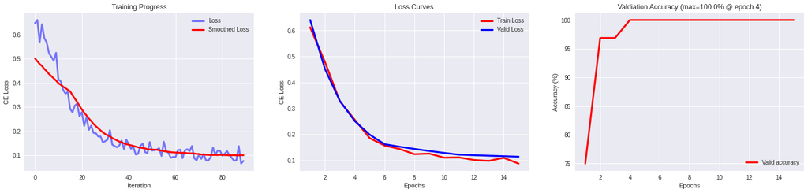

```python
plt.style.use('seaborn')
fig, ax = plt.subplots(1,3)
fig.set_size_inches(24,5)

smooth_loss = smooth(loss_iters, 31)
ax[0].plot(loss_iters, c="blue", label="Loss", linewidth=3, alpha=0.5)
ax[0].plot(smooth_loss, c="red", label="Smoothed Loss", linewidth=3, alpha=1)
ax[0].legend(loc="best")
ax[0].set_xlabel("Iteration")
ax[0].set_ylabel("CE Loss")
ax[0].set_title("Training Progress")

epochs = np.arange(len(train_loss)) + 1
ax[1].plot(epochs, train_loss, c="red", label="Train Loss", linewidth=3)
ax[1].plot(epochs, val_loss, c="blue", label="Valid Loss", linewidth=3)
ax[1].legend(loc="best")
ax[1].set_xlabel("Epochs")
ax[1].set_ylabel("CE Loss")
ax[1].set_title("Loss Curves")

epochs = np.arange(len(val_loss)) + 1
ax[2].plot(epochs, valid_acc, c="red", label="Valid accuracy", linewidth=3)
ax[2].legend(loc="best")
ax[2].set_xlabel("Epochs")
ax[2].set_ylabel("Accuracy (%)")
ax[2].set_title(f"Valdiation Accuracy (max={round(np.max(valid_acc),2)}% @ epoch {np.argmax(valid_acc)+1})")

plt.show()
```

B) Combined Approach

```python
from torchvision.models import convnext_tiny
combinedModel = convnext_tiny(pretrained=True)

for param in combinedModel.parameters():
    param.requires_grad = False

# Replace the classifier with a new trainable MLP head
combinedModel.classifier = nn.Sequential(
    nn.Flatten(start_dim=1),
    nn.LayerNorm(768, eps=1e-6),
    nn.Linear(768, 512),
    nn.ReLU(),
    nn.Dropout(0.2),
    nn.Linear(512, 2)
)


combinedModel = combinedModel.to(device)
```

```python
for name, param in combinedModel.named_parameters():
    if param.requires_grad:
        print(name)
```

```
classifier.1.weight
classifier.1.bias
classifier.2.weight
classifier.2.bias
classifier.5.weight
classifier.5.bias
```

```python
# classification loss function
criterion = nn.CrossEntropyLoss()

# Observe that all parameters are being optimized
optimizer = torch.optim.Adam(combinedModel.parameters(), lr=1e-4)

# Decay LR by a factor of 3 every 5 epochs
scheduler = torch.optim.lr_scheduler.StepLR(optimizer, step_size=5, gamma=1/3)
```

```python
TBOARD_LOGS = os.path.join(os.getcwd(), "tboard_logs", "Task1_Logs", "ConvNext_Combined_Approach")
if not os.path.exists(TBOARD_LOGS):
    os.makedirs(TBOARD_LOGS)

shutil.rmtree(TBOARD_LOGS)
writer = SummaryWriter(TBOARD_LOGS)
```

```python
train_loss, val_loss, loss_iters, valid_acc = train_model(
        model=combinedModel, optimizer=optimizer, scheduler=scheduler, criterion=criterion,
        train_loader=train_loader, valid_loader=val_loader, num_epochs=15, tboard=writer
    )
```

```
    Train loss: 0.65903
    Valid loss: 0.72241
    Accuracy: 50.0%
```

```
    Train loss: 0.17878
    Valid loss: 0.19564
    Accuracy: 96.875%
```

```
    Train loss: 0.13795
    Valid loss: 0.15204
    Accuracy: 96.875%
```

```
    Train loss: 0.11705
    Valid loss: 0.14327
    Accuracy: 96.875%


Training completed
```

Now unfreeze the backbone model

```python
for param in combinedModel.parameters():
    param.requires_grad = True
```

```python
# Lowering learning rate
for g in optimizer.param_groups:
    g['lr'] *= 0.7
```

```python
next_train_loss, next_val_loss, next_loss_iters, next_valid_acc = train_model(
        model=combinedModel, optimizer=optimizer, scheduler=scheduler, criterion=criterion,
        train_loader=train_loader, valid_loader=val_loader, num_epochs=10,  tboard=writer, start_epoch=10
    )
```

```
    Train loss: 0.12077
    Valid loss: 0.14113
    Accuracy: 96.875%
```

```
    Train loss: 0.08322
    Valid loss: 0.11758
    Accuracy: 96.875%
```

```
    Train loss: 0.08037
    Valid loss: 0.11214
    Accuracy: 96.875%


Training completed
```

```python
concat_train_loss = train_loss + next_train_loss
concat_val_loss = val_loss + next_val_loss
concat_loss_iters = loss_iters + next_loss_iters
concat_valid_acc = valid_acc + next_valid_acc
```

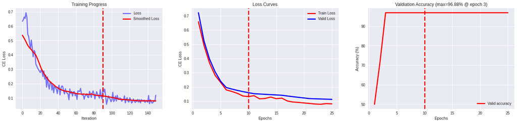

```python
plt.style.use('seaborn')
fig, ax = plt.subplots(1,3)
fig.set_size_inches(24,5)

smooth_loss = smooth(concat_loss_iters, 31)
ax[0].plot(concat_loss_iters, c="blue", label="Loss", linewidth=3, alpha=0.5)
ax[0].plot(smooth_loss, c="red", label="Smoothed Loss", linewidth=3, alpha=1)
ax[0].legend(loc="best")
ax[0].set_xlabel("Iteration")
ax[0].set_ylabel("CE Loss")
ax[0].set_title("Training Progress")
ax[0].axvline(x=len(loss_iters), color="red", ls="--", linewidth=3)

epochs = np.arange(len(concat_train_loss)) + 1
ax[1].plot(epochs, concat_train_loss, c="red", label="Train Loss", linewidth=3)
ax[1].plot(epochs, concat_val_loss, c="blue", label="Valid Loss", linewidth=3)
ax[1].legend(loc="best")
ax[1].set_xlabel("Epochs")
ax[1].set_ylabel("CE Loss")
ax[1].set_title("Loss Curves")
ax[1].axvline(x=10, color="red", ls="--", linewidth=3)

epochs = np.arange(len(concat_val_loss)) + 1
ax[2].plot(epochs, concat_valid_acc, c="red", label="Valid accuracy", linewidth=3)
ax[2].legend(loc="best")
ax[2].set_xlabel("Epochs")
ax[2].set_ylabel("Accuracy (%)")
ax[2].set_title(f"Valdiation Accuracy (max={round(np.max(concat_valid_acc),2)}% @ epoch {np.argmax(concat_valid_acc)+1})")
ax[2].axvline(x=10, color="red", ls="--", linewidth=3)

plt.show()
```

- Compare your CNN based models with a DINOv2-based model used as a fixed feature extractor. Is DINOv2 better?
- Investigate your model. In what types of images does it fail? Why do you think so?
- Evaluate your model on a few images from completely different robots from those seen during training? How does it perform?

# Part 1

```python
import os
from tqdm import tqdm
import numpy as np
import matplotlib.pyplot as plt

import torch
import torch.nn as nn
import torchvision
from torchvision import datasets, models, transforms
import shutil
import torch.nn.functional as F
from torch.utils.tensorboard import SummaryWriter

print(torch.cuda.is_available())
```

[output not shown]

```
True
```

```python
# Data augmentation and normalization for training
# Just normalization for validation
data_transforms = {
    'train': transforms.Compose([
        transforms.RandomResizedCrop(224),
        transforms.RandomHorizontalFlip(),
        transforms.ToTensor(),
        transforms.Normalize([0.485, 0.456, 0.406], [0.229, 0.224, 0.225])
    ]),
    'test': transforms.Compose([
        transforms.Resize(256),
        transforms.CenterCrop(224),
        transforms.ToTensor(),
        transforms.Normalize([0.485, 0.456, 0.406], [0.229, 0.224, 0.225])
    ]),
    'validation': transforms.Compose([
        transforms.Resize(256),
        transforms.CenterCrop(224),
        transforms.ToTensor(),
        transforms.Normalize([0.485, 0.456, 0.406], [0.229, 0.224, 0.225])
    ]),
}

data_dir = '../dataset/'
save_model_dir='../models/'
tensorboard_dir='../tboard_logs/'

train_dataset = datasets.ImageFolder(os.path.join(data_dir, "train"), data_transforms["train"])
valid_dataset = datasets.ImageFolder(os.path.join(data_dir, "val"),data_transforms["validation"])
test_dataset = datasets.ImageFolder(os.path.join(data_dir, "test"),data_transforms["test"])
unseen_dataset = datasets.ImageFolder(os.path.join(data_dir, "unseen_robots"),data_transforms["test"])

N_train = len(train_dataset)
N_valid = len(valid_dataset)
N_test = len(test_dataset)
print(f"Training set size: {N_train} images")
print(f"Valdiation set size: {N_valid} images")
print(f"Test set size: {N_test} images")
print(f"Unseen Robot set size: {len(unseen_dataset)} images")

train_loader = torch.utils.data.DataLoader(train_dataset, batch_size=32, shuffle=True, num_workers=4)
valid_loader = torch.utils.data.DataLoader(valid_dataset, batch_size=32, shuffle=False, num_workers=4)
test_loader = torch.utils.data.DataLoader(test_dataset, batch_size=32, shuffle=False, num_workers=4)
unseen_loader= torch.utils.data.DataLoader(unseen_dataset, batch_size=32, shuffle=False, num_workers=4)
```

```
Training set size: 300 images
Valdiation set size: 60 images
Test set size: 42 images
Unseen Robot set size: 42 images
```

```python
def train_epoch(model, train_loader, optimizer, criterion, epoch, device):
    """ Training a model for one epoch """

    loss_list = []
    for i, (images, labels) in enumerate(train_loader):
        images = images.to(device)
        labels = labels.to(device)

        # Clear gradients w.r.t. parameters
        optimizer.zero_grad()

        # Forward pass to get output/logits
        outputs = model(images)

        # Calculate Loss: softmax --> cross entropy loss
        loss = criterion(outputs, labels)
        loss_list.append(loss.item())

        # Getting gradients w.r.t. parameters
        loss.backward()

        # Updating parameters
        optimizer.step()

    mean_loss = np.mean(loss_list)
    return mean_loss, loss_list

@torch.no_grad()
def eval_model(model, eval_loader, criterion, device,get_false_predictions=False):
    """ Evaluating the model for either validation or test """
    correct = 0
    total = 0
    loss_list = []
    wrong_images = []
    wrong_preds = []
    wrong_labels = []

    for images, labels in eval_loader:
        images = images.to(device)
        labels = labels.to(device)
        # Forward pass only to get logits/output
        outputs = model(images)
        loss = criterion(outputs, labels)
        loss_list.append(loss.item())

        # Get predictions from the maximum value
        preds = torch.argmax(outputs, dim=1)
        #print(f"{preds=}") should be deleted
        wrong_mask = preds != labels
        #print(f"Wrong predictions: {torch.sum(wrong_mask)}") should be deleted
        #print(f"Wrong mask: {wrong_mask=}") should be deleted
        if get_false_predictions and wrong_mask.any():
            wrong_images.append(images[wrong_mask])
            wrong_preds.append(preds[wrong_mask])
            wrong_labels.append(labels[wrong_mask])

        correct += len( torch.where(preds==labels)[0] )
        total += len(labels)

    # Total correct predictions and loss
    accuracy = correct / total * 100
    loss = np.mean(loss_list)

    if(not get_false_predictions):
        return accuracy, loss
    return accuracy, loss, wrong_images, wrong_preds

def train_model(model, optimizer, scheduler, criterion, train_loader, valid_loader, num_epochs, tboard=None, start_epoch=0):
    """ Training a model for a given number of epochs"""

    train_loss = []
    val_loss =  []
    loss_iters = []
    valid_acc = []
    assert tboard is not None, f"Tensorboard must be provided!"

    for epoch in tqdm(range(num_epochs)):

        # validation epoch
        model.eval()  # important for dropout and batch norms
        accuracy, loss = eval_model(
                    model=model, eval_loader=valid_loader,
                    criterion=criterion, device=device
            )
        valid_acc.append(accuracy)
        val_loss.append(loss)
        tboard.add_scalar(f'Accuracy/Valid', accuracy, global_step=epoch+start_epoch)
        tboard.add_scalar(f'Loss/Valid', loss, global_step=epoch+start_epoch)

        # training epoch
        model.train()  # important for dropout and batch norms
        mean_loss, cur_loss_iters = train_epoch(
                model=model, train_loader=train_loader, optimizer=optimizer,
                criterion=criterion, epoch=epoch, device=device
            )
        scheduler.step()
        train_loss.append(mean_loss)
        tboard.add_scalar(f'Loss/Train', mean_loss, global_step=epoch+start_epoch)

        loss_iters = loss_iters + cur_loss_iters

        if(epoch % 5 == 0 or epoch==num_epochs-1):
            print(f"Epoch {epoch+1}/{num_epochs}")
            print(f"    Train loss: {round(mean_loss, 5)}")
            print(f"    Valid loss: {round(loss, 5)}")
            print(f"    Accuracy: {accuracy}%")
            print("\n")

    print(f"Training completed")
    return train_loss, val_loss, loss_iters, valid_acc

def count_model_params(model):
    """ Counting the number of learnable parameters in a nn.Module """
    num_params = sum(p.numel() for p in model.parameters() if p.requires_grad)
    return num_params

def set_random_seed(random_seed=None):
    """
    Using random seed for numpy and torch
    """
    if(random_seed is None):
        random_seed = 13
    os.environ['PYTHONHASHSEED'] = str(random_seed)
    np.random.seed(random_seed)
    torch.manual_seed(random_seed)
    torch.cuda.manual_seed_all(random_seed)
    return

def smooth(f, K=5):
    """ Smoothing a function using a low-pass filter (mean) of size K """
    kernel = np.ones(K) / K
    f = np.concatenate([f[:int(K//2)], f, f[int(-K//2):]])  # to account for boundaries
    smooth_f = np.convolve(f, kernel, mode="same")
    smooth_f = smooth_f[K//2: -K//2]  # removing boundary-fixes
    return smooth_f

def save_model(directory,model, optimizer, epoch, stats):
    """ Saving model checkpoint """

    if(not os.path.exists(f"{directory}")):
        os.makedirs(f"{directory}")
    savepath = f"{directory}checkpoint_epoch_{epoch}.pth"

    torch.save({
        'epoch': epoch,
        'model_state_dict': model.state_dict(),
        'optimizer_state_dict': optimizer.state_dict(),
        'stats': stats
    }, savepath)
    return


def load_model(model, optimizer, savepath,weights_only=False):
    """ Loading pretrained checkpoint """

    checkpoint = torch.load(savepath,weights_only=weights_only)
    #model.load_state_dict(checkpoint['model_state_dict']) ????
    #optimizer.load_state_dict(checkpoint['optimizer_state_dict']) ????
    epoch = checkpoint["epoch"]
    stats = checkpoint["stats"]

    return model, optimizer, epoch, stats

def show_grid(data, titles=None, sup_title=None):
    """Imshow for Tensor."""
    data = data.numpy().transpose((0, 2, 3, 1))
    mean = np.array([0.485, 0.456, 0.406])
    std = np.array([0.229, 0.224, 0.225])
    data = std * data + mean  # IMPORTANT! If you normalize imgs in the DataLoader, undo the norm. for visualization
    data = np.clip(data, 0, 1)

    plt.figure(figsize=(8*2, 4*2))
    for i in range(32):
        if i >= len(data):
            break
        plt.subplot(4,8,i+1)
        plt.imshow(data[i])
        plt.axis("off")
        if sup_title is not None:
            plt.suptitle(sup_title)
        if titles is not None:
            plt.title(titles[i])
    plt.tight_layout()
    plt.show()
```

```python
import timm
from timm.models.vision_transformer import _create_vision_transformer, VisionTransformer
from functools import partial

model_kwargs = dict(
        patch_size=14,
        embed_dim=384,
        depth=12,
        num_heads=6,
        mlp_ratio=4,
        qkv_bias=True,
        norm_layer=partial(nn.LayerNorm, eps=1e-6),
        num_classes=0,
        img_size=224,  # default was 518
    )

dinov2 = timm.create_model(
            "vit_small_patch14_dinov2.lvd142m",
            pretrained=True,
            **model_kwargs
        )
device = torch.device("cuda")
```

```python
set_random_seed()

# Freezing model parameters
for param in dinov2.parameters():
    param.requires_grad = False

# Parameters of newly constructed modules have requires_grad=True by default
num_logits = dinov2.norm.normalized_shape[0]

dinov2.head = nn.Sequential(
    nn.Linear(num_logits, 512),
    nn.ReLU(),
    nn.Dropout(0.2),
    nn.Linear(512, 2)
)
# dinov2.head = nn.Linear(num_logits, 2)

dinov2 = dinov2.to(device)
```

```python
# classification loss function
criterion = nn.CrossEntropyLoss()

# Observe that all parameters are being optimized
optimizer = torch.optim.Adam(dinov2.parameters(), lr=1e-4)

# Decay LR by a factor of 0.3 every 5 epochs
scheduler = torch.optim.lr_scheduler.StepLR(optimizer, step_size=5, gamma=1/3)
```

```python
TBOARD_LOGS = os.path.join(os.getcwd(), f"{tensorboard_dir}", "Transformer", "DINOv2")
if not os.path.exists(TBOARD_LOGS):
    os.makedirs(TBOARD_LOGS)

shutil.rmtree(TBOARD_LOGS)
writer = SummaryWriter(TBOARD_LOGS)
```

```python
train_loss, val_loss, loss_iters, valid_acc = train_model(
        model=dinov2, optimizer=optimizer, scheduler=scheduler, criterion=criterion,
        train_loader=train_loader, valid_loader=valid_loader, num_epochs=15, tboard=writer, start_epoch=0
    )
```

```
    Train loss: 0.48654
    Valid loss: 0.70884
    Accuracy: 55.00000000000001%
```

```
    Train loss: 0.0849
    Valid loss: 0.04827
    Accuracy: 100.0%
```

```
    Train loss: 0.05767
    Valid loss: 0.03817
    Accuracy: 100.0%
```

```
    Train loss: 0.09114
    Valid loss: 0.037
    Accuracy: 100.0%


Training completed
```

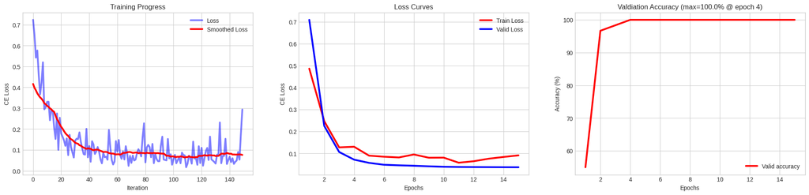

```python
plt.style.use('seaborn-v0_8-whitegrid')
fig, ax = plt.subplots(1,3)
fig.set_size_inches(24,5)

smooth_loss = smooth(loss_iters, 31)
ax[0].plot(loss_iters, c="blue", label="Loss", linewidth=3, alpha=0.5)
ax[0].plot(smooth_loss, c="red", label="Smoothed Loss", linewidth=3, alpha=1)
ax[0].legend(loc="best")
ax[0].set_xlabel("Iteration")
ax[0].set_ylabel("CE Loss")
ax[0].set_title("Training Progress")

epochs = np.arange(len(train_loss)) + 1
ax[1].plot(epochs, train_loss, c="red", label="Train Loss", linewidth=3)
ax[1].plot(epochs, val_loss, c="blue", label="Valid Loss", linewidth=3)
ax[1].legend(loc="best")
ax[1].set_xlabel("Epochs")
ax[1].set_ylabel("CE Loss")
ax[1].set_title("Loss Curves")

epochs = np.arange(len(val_loss)) + 1
ax[2].plot(epochs, valid_acc, c="red", label="Valid accuracy", linewidth=3)
ax[2].legend(loc="best")
ax[2].set_xlabel("Epochs")
ax[2].set_ylabel("Accuracy (%)")
ax[2].set_title(f"Valdiation Accuracy (max={round(np.max(valid_acc),2)}% @ epoch {np.argmax(valid_acc)+1})")

plt.show()
```

```python
dinov2.eval()

accuracy, loss= eval_model(
                    model=dinov2, eval_loader=test_loader,
                    criterion=criterion, device=device
            )

print(f"{accuracy=}, {loss=}")
```

```
accuracy=97.61904761904762, loss=np.float64(0.08725715987384319)
```

```python
save_model(save_model_dir,dinov2, optimizer, len(epochs), stats={"train_loss": train_loss, "val_loss": val_loss, "valid_acc": valid_acc, "test_loss": loss, "test_acc": accuracy})
```

# Part 2

```python
dinov2 = timm.create_model(
            "vit_small_patch14_dinov2.lvd142m",
            pretrained=True,
            **model_kwargs
        )
device = torch.device("cuda")
model=dinov2.to(device)
optimizer = torch.optim.Adam(dinov2.parameters(), lr=1e-5)
criterion = nn.CrossEntropyLoss()

model, optimizer, epoch, stats= load_model(model, optimizer, "../models/checkpoint_epoch_15.pth",weights_only=False)
```

```
False predicted images:
```

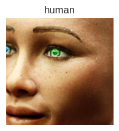

```python
dinov2.to(device)
dinov2.eval()
accuracy, loss,false_predicted_images,false_predicted_labels  = eval_model(
                    model=dinov2, eval_loader=test_loader,
                    criterion=criterion, device=device,get_false_predictions=True
            )
allImages = torch.tensor([]).to(device)
classes = torch.tensor([]).to(device)
class_names = train_dataset.classes
for i in range(len(false_predicted_images)):
    allImages=torch.cat([allImages,false_predicted_images[i]], dim=0)

for i in range(len(false_predicted_labels)):
    classes=torch.cat([classes,false_predicted_labels[i]], dim=0)
titles = [class_names[int(x.item())] for x in classes]
print("False predicted images:")
show_grid(allImages.to("cpu"), titles=titles)
```

#### The model makes mistakes to detect the robots that are deeply looking like humans. In this case, the robot is detectable regarding its eyes. So we have to add more images of robots which are human like but their eyes are different than human to make more sophisticated prediction model.

# Part 3

```python
dinov2 = timm.create_model(
            "vit_small_patch14_dinov2.lvd142m",
            pretrained=True,
            **model_kwargs
        )
device = torch.device("cuda")
model=dinov2.to(device)
optimizer = torch.optim.Adam(dinov2.parameters(), lr=1e-5)
criterion = nn.CrossEntropyLoss()

model, optimizer, epoch, stats= load_model(model, optimizer, "../models/checkpoint_epoch_15.pth",weights_only=False)
```

```
False predicted images:
```

[figure not shown]

```python
dinov2.to(device)
dinov2.eval()
unseen_accuracy, unseen_loss,unseen_false_predicted_images,unseen_false_predicted_labels  = eval_model(
                    model=dinov2, eval_loader=unseen_loader,
                    criterion=criterion, device=device,get_false_predictions=True
            )
allImages = torch.tensor([]).to(device)
classes = torch.tensor([]).to(device)
class_names = train_dataset.classes
for i in range(len(unseen_false_predicted_images)):
    allImages=torch.cat([allImages,unseen_false_predicted_images[i]], dim=0)

for i in range(len(unseen_false_predicted_labels)):
    classes=torch.cat([classes,unseen_false_predicted_labels[i]], dim=0)
titles = [class_names[int(x.item())] for x in classes]
print("False predicted images:")
try:
    show_grid(allImages.to("cpu"), titles=titles)
except:
    print("All the predictions were correct :) ") # We only predict false predicted images.
```

This image was categorized inside the robot folder on purpose, so it is literaly a robot, but our model detects it as a human. That means our model has trained human features very well.

- Extra Point:
  - Fine-tune a Transformer-based model (e.g. SwinTransformer). Compare the performance (accuracy, confusion matrix, training time, loss landscape, ...) with the one from the convolutional models.

```python
from functools import partial
import os, sys
from tqdm import tqdm
from torchmetrics.classification import ConfusionMatrix
import numpy as np
import matplotlib.pyplot as plt
import seaborn as sns
import torch
import torch.nn as nn
import torchvision
from torchvision import datasets, models, transforms
from torch.utils.tensorboard import SummaryWriter
from sklearn.model_selection import train_test_split
sys.path.append(os.path.abspath(os.path.join(os.getcwd(), '..')))
from utils import *
device = torch.device("cuda" if torch.cuda.is_available() else "cpu")
```

### Dataloaders and augmentations

```python
image_size = 224

data_transforms = {
    'train': transforms.Compose([
        transforms.Resize((image_size, image_size)),
        transforms.RandomHorizontalFlip(p=0.5),
        transforms.RandomRotation(35),
        transforms.RandomAdjustSharpness(sharpness_factor=2, p=0.5),
        transforms.ToTensor(),
        transforms.Normalize(
            mean=[0.485, 0.456, 0.406],
            std=[0.229, 0.224, 0.225]
            )
        ]),
    'val': transforms.Compose([
        transforms.Resize((image_size, image_size)),
        transforms.ToTensor(),
        transforms.Normalize(
            mean=[0.485, 0.456, 0.406],
            std=[0.229, 0.224, 0.225]
            )
    ]),
    'test': transforms.Compose([
        transforms.Resize((image_size, image_size)),
        transforms.ToTensor(),
        transforms.Normalize(
            mean=[0.485, 0.456, 0.406],
            std=[0.229, 0.224, 0.225]
        )
])
}

data_dir = os.path.abspath(os.path.join(os.getcwd(), '..','dataset'))

train_dataset = datasets.ImageFolder(os.path.join(data_dir, "train"), data_transforms["train"])
valid_dataset = datasets.ImageFolder(os.path.join(data_dir, "val"), data_transforms["val"])
test_dataset = datasets.ImageFolder(os.path.join(data_dir, "test"), data_transforms['test'])

N_train = len(train_dataset)
N_valid = len(valid_dataset)
N_test = len(test_dataset)
print(f"Training set size: {N_train} images")
print(f"Valdiation set size: {N_valid} images")
print(f"Test set size: {N_test} images")


train_loader = torch.utils.data.DataLoader(train_dataset, batch_size=32, shuffle=True, num_workers=4)
valid_loader = torch.utils.data.DataLoader(valid_dataset, batch_size=32, shuffle=False, num_workers=4)
test_loader = torch.utils.data.DataLoader(test_dataset, batch_size=32, shuffle=False, num_workers=4)
```

```
Training set size: 300 images
Valdiation set size: 60 images
Test set size: 42 images
```

```python
class_names = train_dataset.classes
print(class_names)
```

```
['human', 'robot']
```

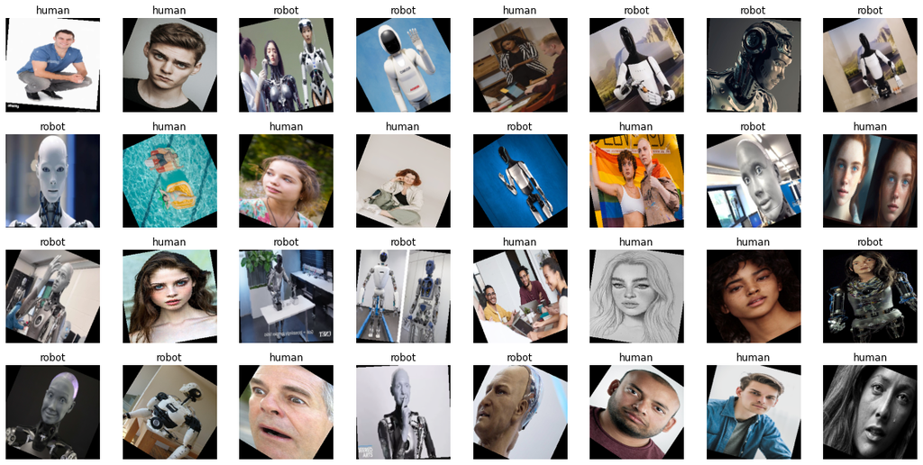

```python
inputs, classes = next(iter(train_loader))
titles = [class_names[x] for x in classes]

show_grid(inputs, titles=titles)
```

```python
from torchsummary import summary

swin_t = models.swin_t(weights='DEFAULT').to(device)
summary(swin_t, input_size= (3,32,32) )
```

```
----------------------------------------------------------------
        Layer (type)               Output Shape         Param #
================================================================
            Conv2d-1             [-1, 96, 8, 8]           4,704
           Permute-2             [-1, 8, 8, 96]               0
         LayerNorm-3             [-1, 8, 8, 96]             192
         LayerNorm-4             [-1, 8, 8, 96]             192
ShiftedWindowAttention-5             [-1, 8, 8, 96]               0
   StochasticDepth-6             [-1, 8, 8, 96]               0
         LayerNorm-7             [-1, 8, 8, 96]             192
            Linear-8            [-1, 8, 8, 384]          37,248
              GELU-9            [-1, 8, 8, 384]               0
          Dropout-10            [-1, 8, 8, 384]               0
           Linear-11             [-1, 8, 8, 96]          36,960
          Dropout-12             [-1, 8, 8, 96]               0
  StochasticDepth-13             [-1, 8, 8, 96]               0
SwinTransformerBlock-14             [-1, 8, 8, 96]               0
        LayerNorm-15             [-1, 8, 8, 96]             192
ShiftedWindowAttention-16             [-1, 8, 8, 96]               0
  StochasticDepth-17             [-1, 8, 8, 96]               0
        LayerNorm-18             [-1, 8, 8, 96]             192
           Linear-19            [-1, 8, 8, 384]          37,248
             GELU-20            [-1, 8, 8, 384]               0
          Dropout-21            [-1, 8, 8, 384]               0
           Linear-22             [-1, 8, 8, 96]          36,960
          Dropout-23             [-1, 8, 8, 96]               0
  StochasticDepth-24             [-1, 8, 8, 96]               0
SwinTransformerBlock-25             [-1, 8, 8, 96]               0
        LayerNorm-26            [-1, 4, 4, 384]             768
           Linear-27            [-1, 4, 4, 192]          73,728
     PatchMerging-28            [-1, 4, 4, 192]               0
        LayerNorm-29            [-1, 4, 4, 192]             384
ShiftedWindowAttention-30            [-1, 4, 4, 192]               0
  StochasticDepth-31            [-1, 4, 4, 192]               0
        LayerNorm-32            [-1, 4, 4, 192]             384
           Linear-33            [-1, 4, 4, 768]         148,224
             GELU-34            [-1, 4, 4, 768]               0
          Dropout-35            [-1, 4, 4, 768]               0
           Linear-36            [-1, 4, 4, 192]         147,648
          Dropout-37            [-1, 4, 4, 192]               0
```

[output cut: 105 more lines]

```
 StochasticDepth-143            [-1, 1, 1, 768]               0
SwinTransformerBlock-144            [-1, 1, 1, 768]               0
       LayerNorm-145            [-1, 1, 1, 768]           1,536
AdaptiveAvgPool2d-146            [-1, 768, 1, 1]               0
          Linear-147                 [-1, 1000]         769,000
================================================================
Total params: 19,621,192
Trainable params: 19,621,192
Non-trainable params: 0
----------------------------------------------------------------
Input size (MB): 0.01
Forward/backward pass size (MB): 4.78
Params size (MB): 74.85
Estimated Total Size (MB): 79.64
----------------------------------------------------------------
```

## Running evaluation before fine-tuning the model on our own dataset

```python
criterion = nn.CrossEntropyLoss()

accuracy, loss = eval_model(swin_t, eval_loader= test_loader, criterion= criterion, device= device)

print("Evaluation Accuracy before fine-tuning:" , accuracy)
print('Evaluation Loss before fine-tuning: ', loss)
```

```
Evaluation Accuracy before fine-tuning: 0.0
Evaluation Loss before fine-tuning:  8.374700546264648
```

### 1. End-to-end fine tuining

```python
swin_t = models.swin_t(weights='DEFAULT').to(device)

num_logits = swin_t.head.in_features

swin_t.head = nn.Sequential(
    nn.Linear(num_logits, 512),
    nn.ReLU(),
    nn.Dropout(0.2),
    nn.Linear(512, 2)
)
swin_t.to(device)
summary(swin_t, input_size= (3,32,32) )
```

```
----------------------------------------------------------------
        Layer (type)               Output Shape         Param #
================================================================
            Conv2d-1             [-1, 96, 8, 8]           4,704
           Permute-2             [-1, 8, 8, 96]               0
         LayerNorm-3             [-1, 8, 8, 96]             192
         LayerNorm-4             [-1, 8, 8, 96]             192
ShiftedWindowAttention-5             [-1, 8, 8, 96]               0
   StochasticDepth-6             [-1, 8, 8, 96]               0
         LayerNorm-7             [-1, 8, 8, 96]             192
            Linear-8            [-1, 8, 8, 384]          37,248
              GELU-9            [-1, 8, 8, 384]               0
          Dropout-10            [-1, 8, 8, 384]               0
           Linear-11             [-1, 8, 8, 96]          36,960
          Dropout-12             [-1, 8, 8, 96]               0
  StochasticDepth-13             [-1, 8, 8, 96]               0
SwinTransformerBlock-14             [-1, 8, 8, 96]               0
        LayerNorm-15             [-1, 8, 8, 96]             192
ShiftedWindowAttention-16             [-1, 8, 8, 96]               0
  StochasticDepth-17             [-1, 8, 8, 96]               0
        LayerNorm-18             [-1, 8, 8, 96]             192
           Linear-19            [-1, 8, 8, 384]          37,248
             GELU-20            [-1, 8, 8, 384]               0
          Dropout-21            [-1, 8, 8, 384]               0
           Linear-22             [-1, 8, 8, 96]          36,960
          Dropout-23             [-1, 8, 8, 96]               0
  StochasticDepth-24             [-1, 8, 8, 96]               0
SwinTransformerBlock-25             [-1, 8, 8, 96]               0
        LayerNorm-26            [-1, 4, 4, 384]             768
           Linear-27            [-1, 4, 4, 192]          73,728
     PatchMerging-28            [-1, 4, 4, 192]               0
        LayerNorm-29            [-1, 4, 4, 192]             384
ShiftedWindowAttention-30            [-1, 4, 4, 192]               0
  StochasticDepth-31            [-1, 4, 4, 192]               0
        LayerNorm-32            [-1, 4, 4, 192]             384
           Linear-33            [-1, 4, 4, 768]         148,224
             GELU-34            [-1, 4, 4, 768]               0
          Dropout-35            [-1, 4, 4, 768]               0
           Linear-36            [-1, 4, 4, 192]         147,648
          Dropout-37            [-1, 4, 4, 192]               0
```

[output cut: 108 more lines]

```
AdaptiveAvgPool2d-146            [-1, 768, 1, 1]               0
          Linear-147                  [-1, 512]         393,728
            ReLU-148                  [-1, 512]               0
         Dropout-149                  [-1, 512]               0
          Linear-150                    [-1, 2]           1,026
================================================================
Total params: 19,246,946
Trainable params: 19,246,946
Non-trainable params: 0
----------------------------------------------------------------
Input size (MB): 0.01
Forward/backward pass size (MB): 4.78
Params size (MB): 73.42
Estimated Total Size (MB): 78.21
----------------------------------------------------------------
```

```python
set_random_seed()
```

```python
criterion = nn.CrossEntropyLoss()

optimizer = torch.optim.Adam(swin_t.parameters(), lr=1e-4)

scheduler = torch.optim.lr_scheduler.CosineAnnealingWarmRestarts(optimizer, T_0=5, T_mult=2)
```

```python
# TODO: remove the ".." when integrated in the combined file

TBOARD_LOGS = os.path.join(os.getcwd(),"..", "tboard_logs", "Transformer", "SwinTransformer")

if os.path.exists(TBOARD_LOGS):
    shutil.rmtree(TBOARD_LOGS) # To discard old log files

os.makedirs(TBOARD_LOGS)

writer = SummaryWriter(TBOARD_LOGS)
```

```python
train_loss, val_loss, loss_iters, valid_acc = train_model(
        model=swin_t, optimizer=optimizer, scheduler=scheduler, criterion=criterion,
        train_loader=train_loader, valid_loader=valid_loader, num_epochs=15, tboard=writer, start_epoch=0
    )
```

```
    Train loss: 0.43114
    Valid loss: 0.67089
    Accuracy: 56.666666666666664%
```

```
    Train loss: 0.01025
    Valid loss: 0.00245
    Accuracy: 100.0%
```

```
    Train loss: 0.00031
    Valid loss: 7e-05
    Accuracy: 100.0%
```

```
    Train loss: 0.00222
    Valid loss: 6e-05
    Accuracy: 100.0%


Training completed
```

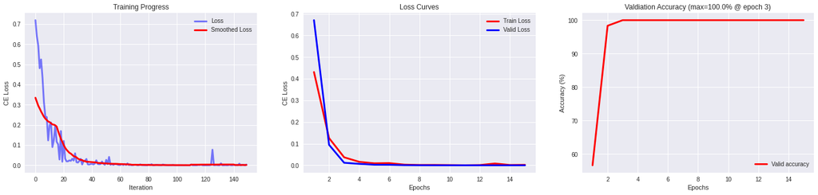

```python
plot(train_loss, val_loss, loss_iters, valid_acc)
```

### Evaluation

```python
accuracy, loss = eval_model(swin_t, eval_loader= test_loader, criterion= criterion, device= device)

print("Evaluation Accuracy before fine-tuning:" , accuracy)
print('Evaluation Loss before fine-tuning: ', loss)
```

```
Evaluation Accuracy before fine-tuning: 97.61904761904762
Evaluation Loss before fine-tuning:  0.04013639804907143
```

### 2. Fine-tuning with freezing backbone

```python
from torchinfo import summary

swin_t = models.swin_t(weights='DEFAULT').to(device)

for param in swin_t.parameters():
    param.requires_grad = False

swin_t.head = nn.Sequential(
    nn.Linear(num_logits, 512),
    nn.ReLU(),
    nn.Dropout(0.2),
    nn.Linear(512, 2)
)

summary(swin_t, col_names=[ "num_params",'trainable'], col_width=14)
```

```
==============================================================================
Layer (type:depth-idx)                             Param #        Trainable
==============================================================================
SwinTransformer                                    --             Partial
├─Sequential: 1-1                                  --             False
│    └─Sequential: 2-1                             --             False
│    │    └─Conv2d: 3-1                            (4,704)        False
│    │    └─Permute: 3-2                           --             --
│    │    └─LayerNorm: 3-3                         (192)          False
│    └─Sequential: 2-2                             --             False
│    │    └─SwinTransformerBlock: 3-4              (112,347)      False
│    │    └─SwinTransformerBlock: 3-5              (112,347)      False
│    └─PatchMerging: 2-3                           --             False
│    │    └─Linear: 3-6                            (73,728)       False
│    │    └─LayerNorm: 3-7                         (768)          False
│    └─Sequential: 2-4                             --             False
│    │    └─SwinTransformerBlock: 3-8              (445,878)      False
│    │    └─SwinTransformerBlock: 3-9              (445,878)      False
│    └─PatchMerging: 2-5                           --             False
│    │    └─Linear: 3-10                           (294,912)      False
│    │    └─LayerNorm: 3-11                        (1,536)        False
│    └─Sequential: 2-6                             --             False
│    │    └─SwinTransformerBlock: 3-12             (1,776,492)    False
│    │    └─SwinTransformerBlock: 3-13             (1,776,492)    False
│    │    └─SwinTransformerBlock: 3-14             (1,776,492)    False
│    │    └─SwinTransformerBlock: 3-15             (1,776,492)    False
│    │    └─SwinTransformerBlock: 3-16             (1,776,492)    False
│    │    └─SwinTransformerBlock: 3-17             (1,776,492)    False
│    └─PatchMerging: 2-7                           --             False
│    │    └─Linear: 3-18                           (1,179,648)    False
│    │    └─LayerNorm: 3-19                        (3,072)        False
│    └─Sequential: 2-8                             --             False
│    │    └─SwinTransformerBlock: 3-20             (7,091,928)    False
│    │    └─SwinTransformerBlock: 3-21             (7,091,928)    False
├─LayerNorm: 1-2                                   (1,536)        False
├─AdaptiveAvgPool2d: 1-3                           --             --
├─Sequential: 1-4                                  --             True
│    └─Linear: 2-9                                 393,728        True
│    └─ReLU: 2-10                                  --             --
│    └─Dropout: 2-11                               --             --
│    └─Linear: 2-12                                1,026          True
==============================================================================
Total params: 27,914,108
Trainable params: 394,754
Non-trainable params: 27,519,354
==============================================================================
```

```python
criterion = nn.CrossEntropyLoss()
optimizer = torch.optim.Adam(swin_t.parameters(), lr=1e-4)
scheduler = torch.optim.lr_scheduler.StepLR(optimizer, step_size=5, gamma=1/3)

train_loss, val_loss, loss_iters, valid_acc = train_model(
        model=swin_t, optimizer=optimizer, scheduler=scheduler, criterion=criterion,
        train_loader=train_loader, valid_loader=valid_loader, num_epochs=15, tboard=writer, start_epoch=0
    )
```

```
    Train loss: 0.63622
    Valid loss: 0.66395
    Accuracy: 66.66666666666666%
```

```
    Train loss: 0.23548
    Valid loss: 0.18026
    Accuracy: 98.33333333333333%
```

```
    Train loss: 0.17522
    Valid loss: 0.13254
    Accuracy: 98.33333333333333%
```

```
    Train loss: 0.15736
    Valid loss: 0.12236
    Accuracy: 98.33333333333333%


Training completed
```

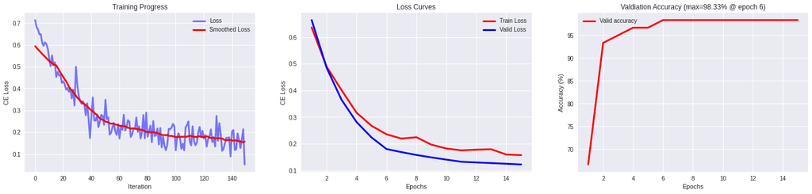

```python
plot(train_loss, val_loss, loss_iters, valid_acc)
```